# Graficación ggplot2

Kenneth Roy Cabrera Torres

27 de agosto de 2015

## ¿Qué es ggplot2?

- Es una construcción de la “Gramática de las gráficas” (Grammar Graphics) propuesta por Leland Wilkinson.
- Escrito por Hadley Wickham (como estudiante de Iowa State).
- Está disponible en CRAN y se installa como un paquete del CRAN.
- La gramática de las gráficas representa una abtracción de gráficas e ideas.
- Similar a pensar en “verbos”, “sustantivos” y “adjetivos” para las gráficas.
- La teoría propone una construcción de gráficas mediante una sucesión de elementos similar a un lenguaje.
- La idea es acortar la distancia entre lo que se piensa y lo que se grafica.

“En resumen, la gramática nos dice que una gráfica estadística es un mapa de los datos a unos atributos estéticos (color, forma, tamaño) de unos objetos geométricos (puntos, lineas, barras). La gráfica tendrá transformaciones estadísticas que se trazan en sistemas de coordenadas específicas”

## La función qplot()

- Trabaja similar a la función *plot* en el sistema básico.
- Se le indica una base de datos, unos elementos *estéticos* y una *geometría*.
- Se recomienda trabajar con la composición para tener más dominio de la gramática.

## Paquete ggplot2

```r
require(ggplot2)
```

## Bases de datos mpg (Rendimiento de automóviles)

```r
str(mpg)
```

```
## 'data.frame':    234 obs. of  11 variables:
##  $ manufacturer: Factor w/ 15 levels "audi","chevrolet",..: 1 1 1 1 1 1 1 1 1 1 ...
##  $ model       : Factor w/ 38 levels "4runner 4wd",..: 2 2 2 2 2 2 2 3 3 3 ...
##  $ displ       : num  1.8 1.8 2 2 2.8 2.8 3.1 1.8 1.8 2 ...
##  $ year        : int  1999 1999 2008 2008 1999 1999 2008 1999 1999 2008 ...
##  $ cyl         : int  4 4 4 4 6 6 6 4 4 4 ...
##  $ trans       : Factor w/ 10 levels "auto(av)","auto(l3)",..: 4 9 10 1 4 9 1 9 4 10 ...
##  $ drv         : Factor w/ 3 levels "4","f","r": 2 2 2 2 2 2 2 1 1 1 ...
##  $ cty         : int  18 21 20 21 16 18 18 18 16 20 ...
##  $ hwy         : int  29 29 31 30 26 26 27 26 25 28 ...
##  $ fl          : Factor w/ 5 levels "c","d","e","p",..: 4 4 4 4 4 4 4 4 4 4 ...
##  $ class       : Factor w/ 7 levels "2seater","compact",..: 2 2 2 2 2 2 2 2 2 2 ...
```

```r
head(mpg)
```

```
##   manufacturer model displ year cyl      trans drv cty hwy fl   class
## 1         audi    a4   1.8 1999   4   auto(l5)   f  18  29  p compact
## 2         audi    a4   1.8 1999   4 manual(m5)   f  21  29  p compact
## 3         audi    a4   2.0 2008   4 manual(m6)   f  20  31  p compact
## 4         audi    a4   2.0 2008   4   auto(av)   f  21  30  p compact
## 5         audi    a4   2.8 1999   6   auto(l5)   f  16  26  p compact
## 6         audi    a4   2.8 1999   6 manual(m5)   f  18  26  p compact
```

### Explicación de las variables

- manufacturer. Fabricantes.
- model. Modelo.
- displ. Volumen del cilindraje o volumen de desplazamiento en litros.
- year. Año,
- cyl. Número de cilindros,
- trans. Tipo de transmisión,
- drv. Conducción. f = frontal, r = posterior, 4 = 4 ruedas.
- cty. Millas por galón en ciudad.
- hwy. Millas por galón en autopista.
- fl. Combustible e= etanol, r = gasolina corriente, d = disel, c = gas natural, p = gasolina extra.
- class. Clase.

Clasificación de vehículos: (https://en.wikipedia.org/wiki/Car_classification#Size_and_usage-based_vehicle_classification_systems_worldwide)

### Primera gráfica

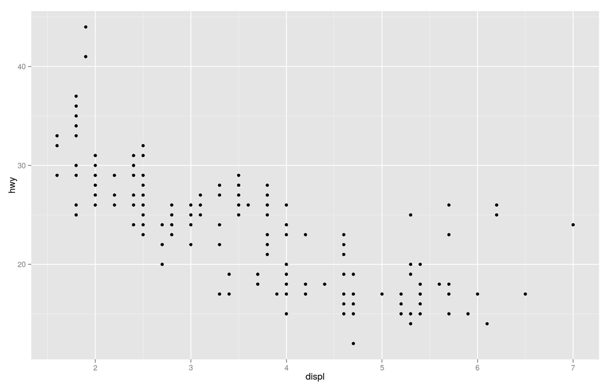

```r
g1 <- ggplot(mpg, aes(displ, hwy))
g1 + geom_point()
```

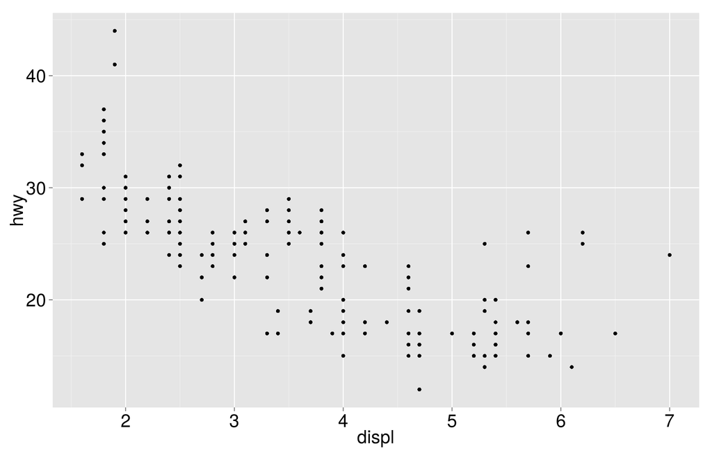

```r
g1 <- ggplot(mpg, aes(displ, hwy))
g1 + geom_point()+
theme(axis.title.y = element_text(size=20),
      axis.title.x = element_text(size=20),
      axis.text.x=element_text(size = 20, color = "black"),
      axis.text.y=element_text(color="black", size= 20))
```

### Segunda gráfica

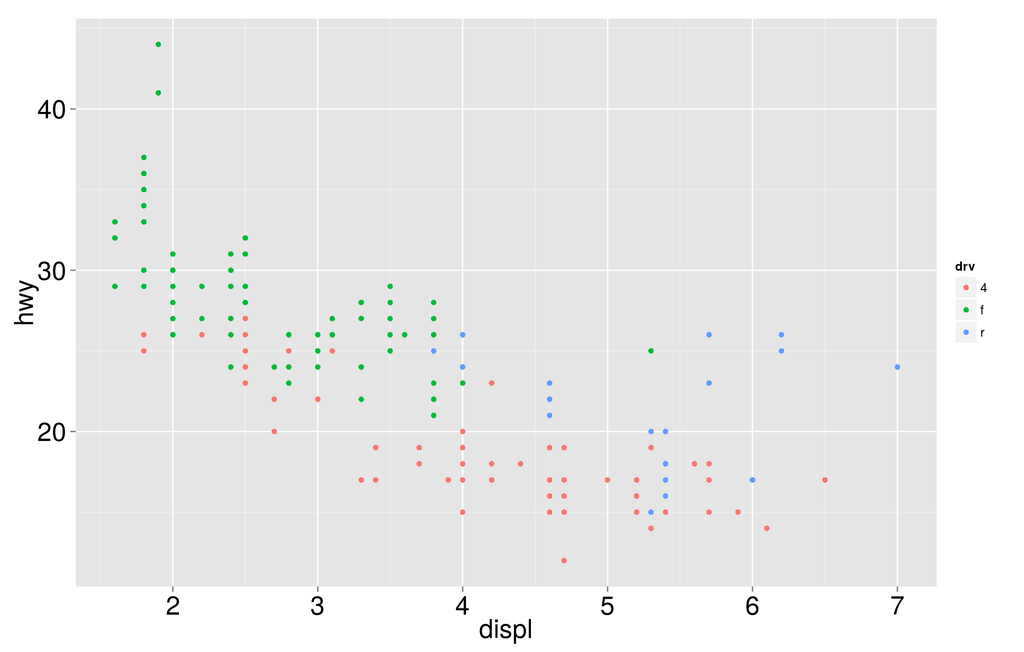

```r
g1 <- ggplot(mpg, aes(displ, hwy, col = drv))
g1 + geom_point()+
theme(axis.title.y = element_text(size=20),
      axis.title.x = element_text(size=20),
      axis.text.x=element_text(size = 20, color = "black"),
      axis.text.y=element_text(color="black", size= 20))
```

### Adición de una “geom_”

```
## geom_smooth: method="auto" and size of largest group is <1000, so using loess. Use 'method = x' to change the smoothing method.
```

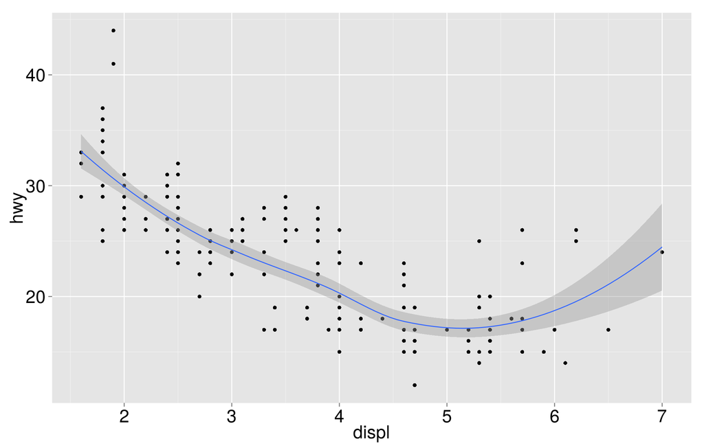

```r
g1 <- ggplot(mpg, aes(displ, hwy))
g1 + geom_point() + geom_smooth()+
theme(axis.title.y = element_text(size=20),
      axis.title.x = element_text(size=20),
      axis.text.x=element_text(size = 20, color = "black"),
      axis.text.y=element_text(color="black", size= 20))
```

### Histograma

```
## stat_bin: binwidth defaulted to range/30. Use 'binwidth = x' to adjust this.
```

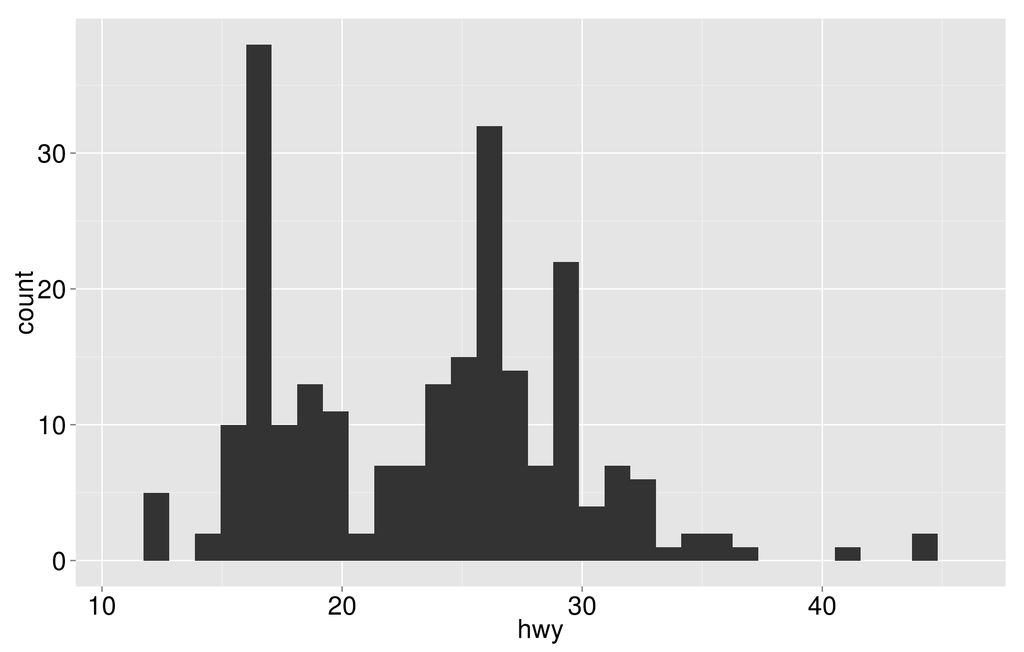

```r
g1 <- ggplot(mpg, aes(hwy))
g1 + geom_histogram()+
theme(axis.title.y = element_text(size=20),
      axis.title.x = element_text(size=20),
      axis.text.x=element_text(size = 20, color = "black"),
      axis.text.y=element_text(color="black", size= 20))
```

```
## stat_bin: binwidth defaulted to range/30. Use 'binwidth = x' to adjust this.
```

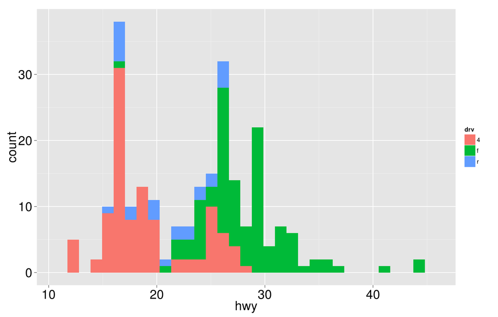

```r
g1 <- ggplot(mpg, aes(hwy, fill = drv))
g1 + geom_histogram()+
theme(axis.title.y = element_text(size=20),
      axis.title.x = element_text(size=20),
      axis.text.x=element_text(size = 20, color = "black"),
      axis.text.y=element_text(color="black", size= 20))
```

### Facetas (páneles)

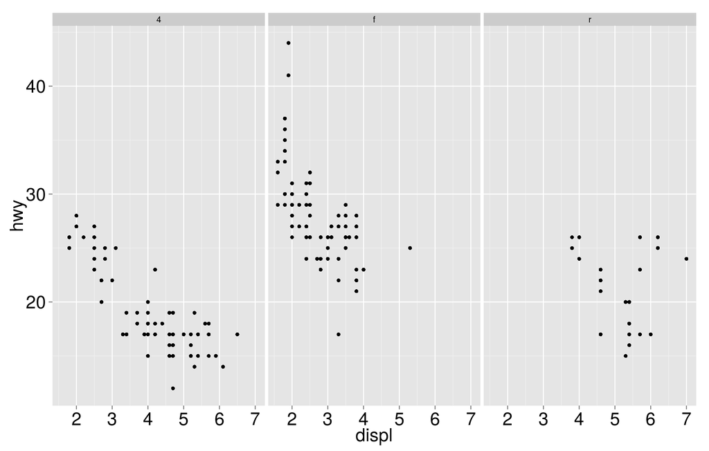

```r
g1 <- ggplot(mpg, aes(displ, hwy))
g1 + geom_point() + facet_grid( . ~ drv)+
theme(axis.title.y = element_text(size=20),
      axis.title.x = element_text(size=20),
      axis.text.x=element_text(size = 20, color = "black"),
      axis.text.y=element_text(color="black", size= 20))
```

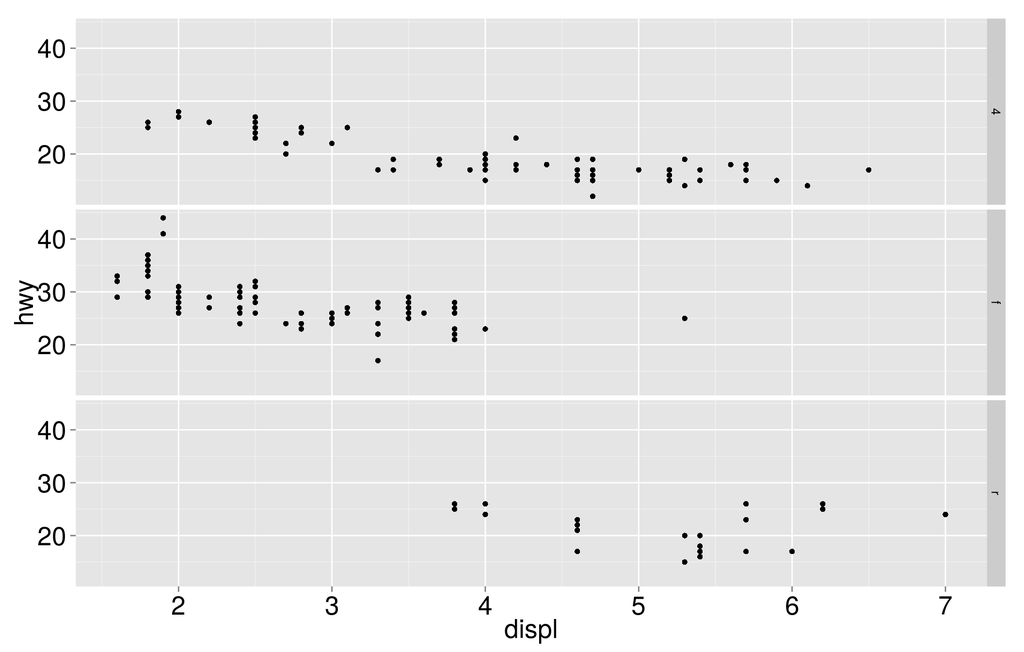

```r
g1 <- ggplot(mpg, aes(displ, hwy))
g1 + geom_point() + facet_grid( drv ~ .)+
theme(axis.title.y = element_text(size=20),
      axis.title.x = element_text(size=20),
      axis.text.x=element_text(size = 20, color = "black"),
      axis.text.y=element_text(color="black", size= 20))
```

```
## stat_bin: binwidth defaulted to range/30. Use 'binwidth = x' to adjust this.
## stat_bin: binwidth defaulted to range/30. Use 'binwidth = x' to adjust this.
## stat_bin: binwidth defaulted to range/30. Use 'binwidth = x' to adjust this.
```

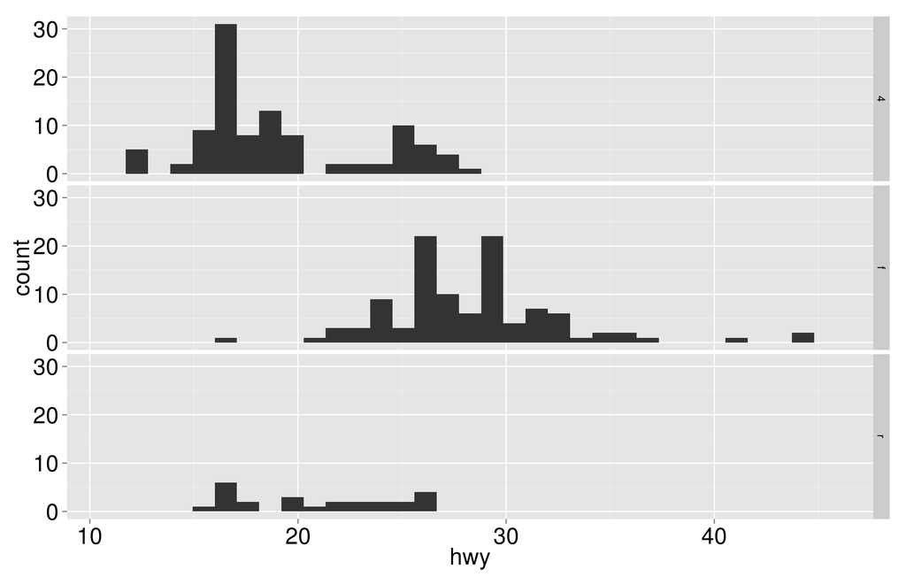

```r
g1 <- ggplot(mpg, aes(hwy))
g1 + geom_histogram() + facet_grid( drv ~ .)+
theme(axis.title.y = element_text(size=20),
      axis.title.x = element_text(size=20),
      axis.text.x=element_text(size = 20, color = "black"),
      axis.text.y=element_text(color="black", size= 20))
```

## Base de datos “Calidad del aire”

```r
str(airquality)
```

```
## 'data.frame':    153 obs. of  6 variables:
##  $ Ozone  : int  41 36 12 18 NA 28 23 19 8 NA ...
##  $ Solar.R: int  190 118 149 313 NA NA 299 99 19 194 ...
##  $ Wind   : num  7.4 8 12.6 11.5 14.3 14.9 8.6 13.8 20.1 8.6 ...
##  $ Temp   : int  67 72 74 62 56 66 65 59 61 69 ...
##  $ Month  : int  5 5 5 5 5 5 5 5 5 5 ...
##  $ Day    : int  1 2 3 4 5 6 7 8 9 10 ...
```

```r
head(airquality)
```

```
##   Ozone Solar.R Wind Temp Month Day
## 1    41     190  7.4   67     5   1
## 2    36     118  8.0   72     5   2
## 3    12     149 12.6   74     5   3
## 4    18     313 11.5   62     5   4
## 5    NA      NA 14.3   56     5   5
## 6    28      NA 14.9   66     5   6
```

### Explicación de las variables

- Ozone: Ozono (ppb, partes por miles de millones)
- Solar.R: Radiación solar en Langleys. 1 Lang = 41840 J/m2. Del espectro entre 4000 y 7700 Angstroms o de 400 a 770 nm desde las 8:00 a las 12:00 horas en el Central Park.
- Wind: Velocidad promedio del viento entre las 7:00 y 10:00 en el Aeropuerto La Guardia.
- Temp: Temperatura máxima en grados Fahrenheit en el Aeropuerto La Guardia.
- Month: Número del mes 1-12
- Day: Día del mes 1-31

### Calidad del aire

```
## stat_bin: binwidth defaulted to range/30. Use 'binwidth = x' to adjust this.
```

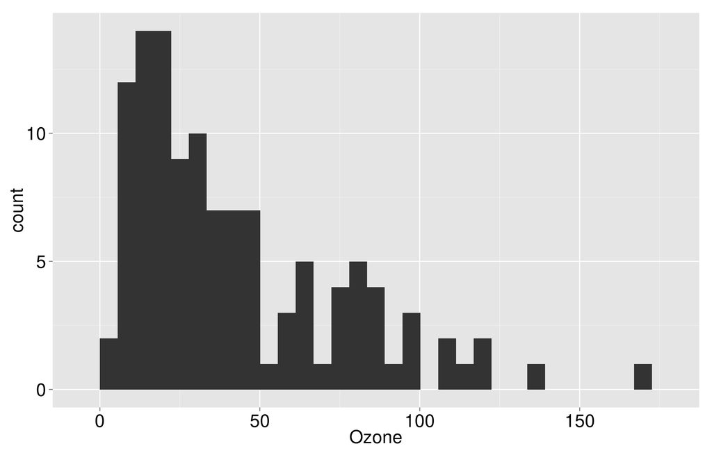

```r
require(ggplot2)
g1 <- ggplot(airquality, aes(Ozone))
g1 + geom_histogram()+
theme(axis.title.y = element_text(size=20),
      axis.title.x = element_text(size=20),
      axis.text.x=element_text(size = 20, color = "black"),
      axis.text.y=element_text(color="black", size= 20))
```

```
## stat_bin: binwidth defaulted to range/30. Use 'binwidth = x' to adjust this.
```

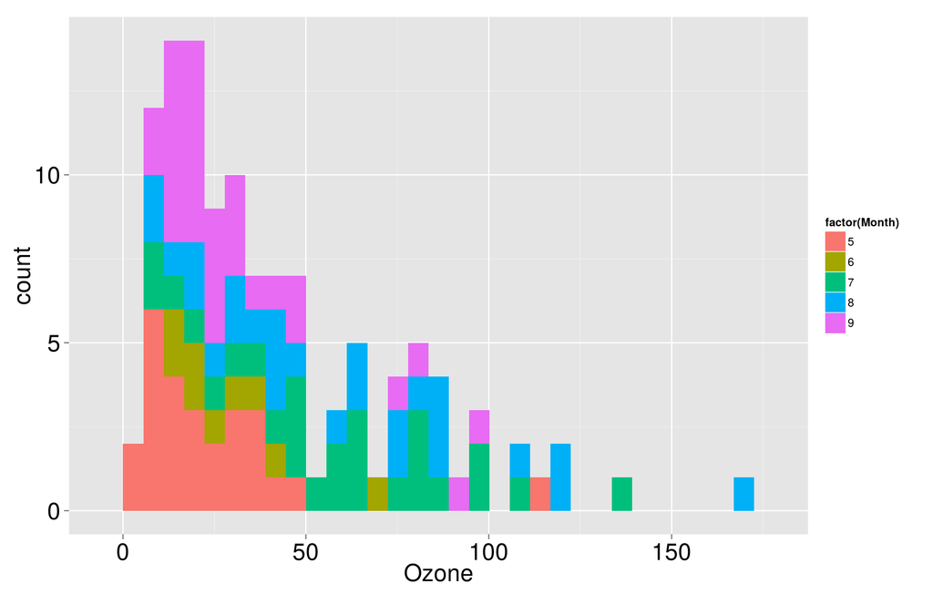

```r
require(ggplot2)
g1 <- ggplot(airquality, aes(Ozone, fill = factor(Month)))
g1 + geom_histogram()+
theme(axis.title.y = element_text(size=20),
      axis.title.x = element_text(size=20),
      axis.text.x=element_text(size = 20, color = "black"),
      axis.text.y=element_text(color="black", size= 20))
```

### Distribución

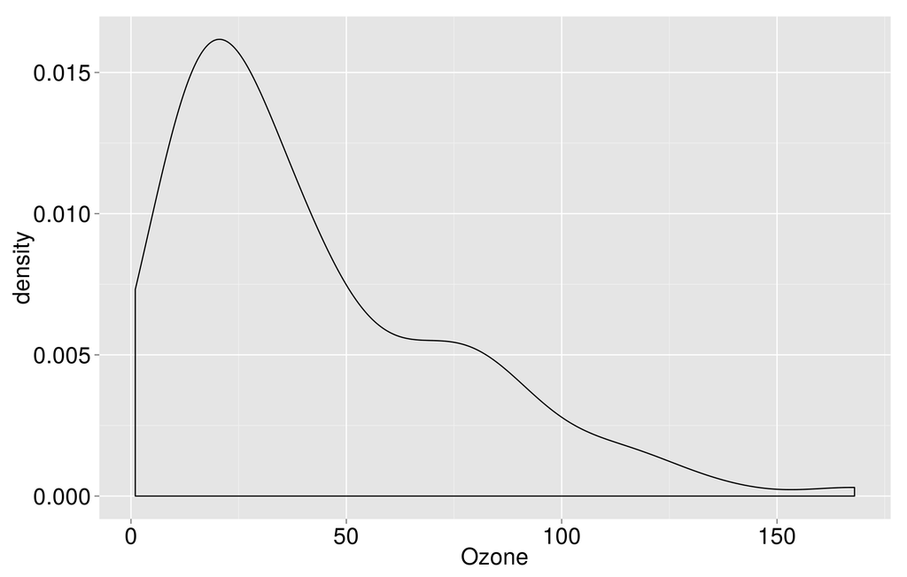

```r
require(ggplot2)
g1 <- ggplot(airquality, aes(Ozone))
g1 + geom_density()+
theme(axis.title.y = element_text(size=20),
      axis.title.x = element_text(size=20),
      axis.text.x=element_text(size = 20, color = "black"),
      axis.text.y=element_text(color="black", size= 20))
```

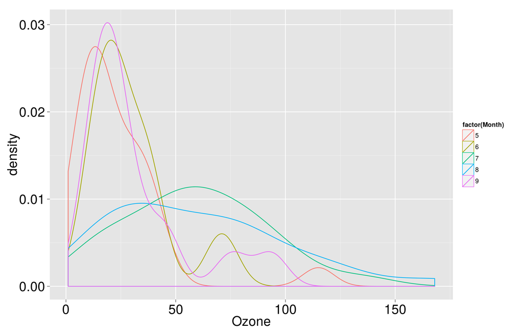

```r
require(ggplot2)
g1 <- ggplot(airquality, aes(Ozone, col = factor(Month)))
g1 + geom_density()+
theme(axis.title.y = element_text(size=20),
      axis.title.x = element_text(size=20),
      axis.text.x=element_text(size = 20, color = "black"),
      axis.text.y=element_text(color="black", size= 20))
```

### Diagrama de dispersión

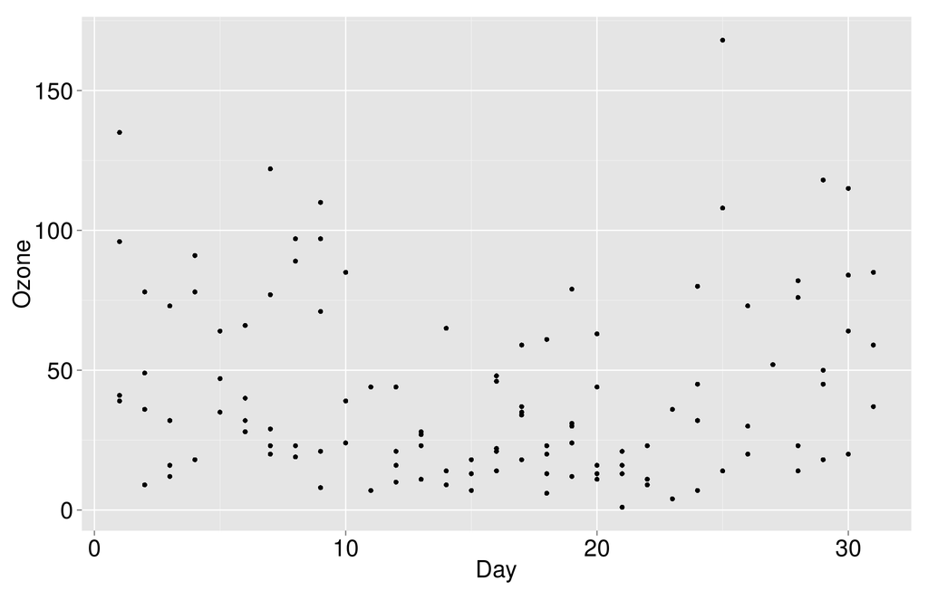

```r
require(ggplot2)
g1 <- ggplot(airquality, aes(Day, Ozone))
g1 + geom_point()+
theme(axis.title.y = element_text(size=20),
      axis.title.x = element_text(size=20),
      axis.text.x=element_text(size = 20, color = "black"),
      axis.text.y=element_text(color="black", size= 20))
```

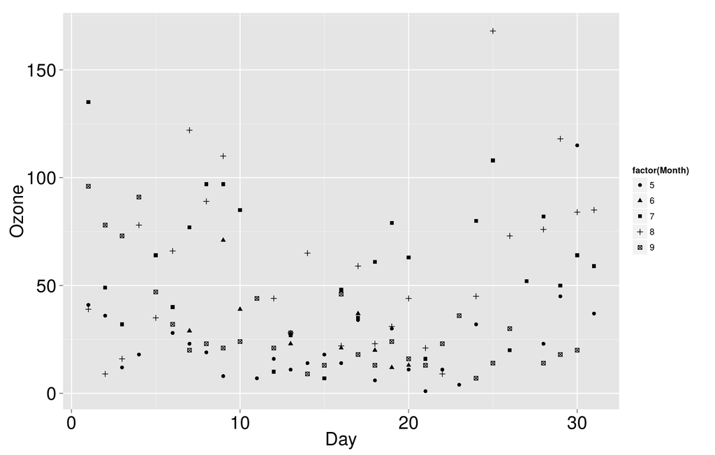

```r
require(ggplot2)
g1 <- ggplot(airquality, aes(Day, Ozone, shape=factor(Month)))
g1 + geom_point()+
theme(axis.title.y = element_text(size=20),
      axis.title.x = element_text(size=20),
      axis.text.x=element_text(size = 20, color = "black"),
      axis.text.y=element_text(color="black", size= 20))
```

### Series de tiempo

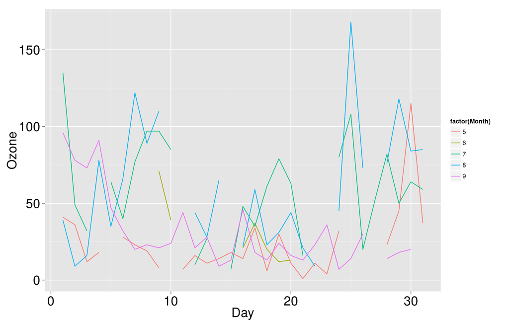

```r
require(ggplot2)
g1 <- ggplot(airquality, aes(Day, Ozone, col=factor(Month)))
g1 + geom_line()+
theme(axis.title.y = element_text(size=20),
      axis.title.x = element_text(size=20),
      axis.text.x=element_text(size = 20, color = "black"),
      axis.text.y=element_text(color="black", size= 20))
```

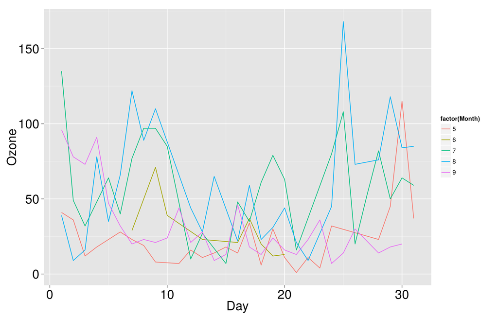

```r
require(ggplot2)
g1 <- ggplot(subset(airquality, !is.na(Ozone)),
             aes(Day, Ozone, col=factor(Month)))
g1 + geom_line()+
theme(axis.title.y = element_text(size=20),
      axis.title.x = element_text(size=20),
      axis.text.x=element_text(size = 20, color = "black"),
      axis.text.y=element_text(color="black", size= 20))
```

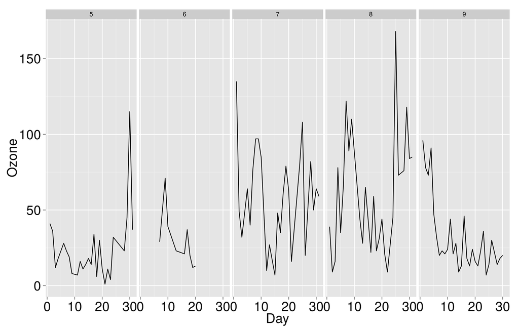

```r
require(ggplot2)
g1 <- ggplot(subset(airquality, !is.na(Ozone)),
             aes(Day, Ozone))
g1 + geom_line() + facet_grid(. ~ Month)+
theme(axis.title.y = element_text(size=20),
      axis.title.x = element_text(size=20),
      axis.text.x=element_text(size = 20, color = "black"),
      axis.text.y=element_text(color="black", size= 20))
```

```
## geom_smooth: method="auto" and size of largest group is <1000, so using loess. Use 'method = x' to change the smoothing method.
## geom_smooth: method="auto" and size of largest group is <1000, so using loess. Use 'method = x' to change the smoothing method.
## geom_smooth: method="auto" and size of largest group is <1000, so using loess. Use 'method = x' to change the smoothing method.
## geom_smooth: method="auto" and size of largest group is <1000, so using loess. Use 'method = x' to change the smoothing method.
## geom_smooth: method="auto" and size of largest group is <1000, so using loess. Use 'method = x' to change the smoothing method.
```

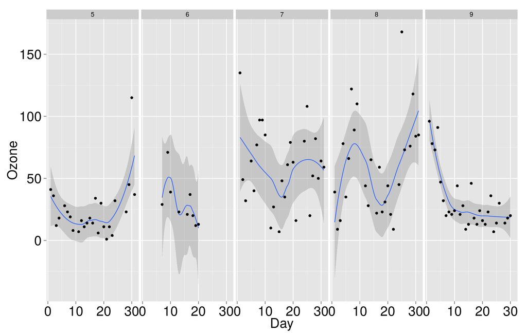

```r
require(ggplot2)
g1 <- ggplot(subset(airquality, !is.na(Ozone)),
             aes(Day, Ozone))
g1 + geom_smooth() + facet_grid(. ~ Month) + geom_point()+
theme(axis.title.y = element_text(size=20),
      axis.title.x = element_text(size=20),
      axis.text.x=element_text(size = 20, color = "black"),
      axis.text.y=element_text(color="black", size= 20))
```

### Anotaciones

```
## geom_smooth: method="auto" and size of largest group is <1000, so using loess. Use 'method = x' to change the smoothing method.
## geom_smooth: method="auto" and size of largest group is <1000, so using loess. Use 'method = x' to change the smoothing method.
## geom_smooth: method="auto" and size of largest group is <1000, so using loess. Use 'method = x' to change the smoothing method.
## geom_smooth: method="auto" and size of largest group is <1000, so using loess. Use 'method = x' to change the smoothing method.
## geom_smooth: method="auto" and size of largest group is <1000, so using loess. Use 'method = x' to change the smoothing method.
```

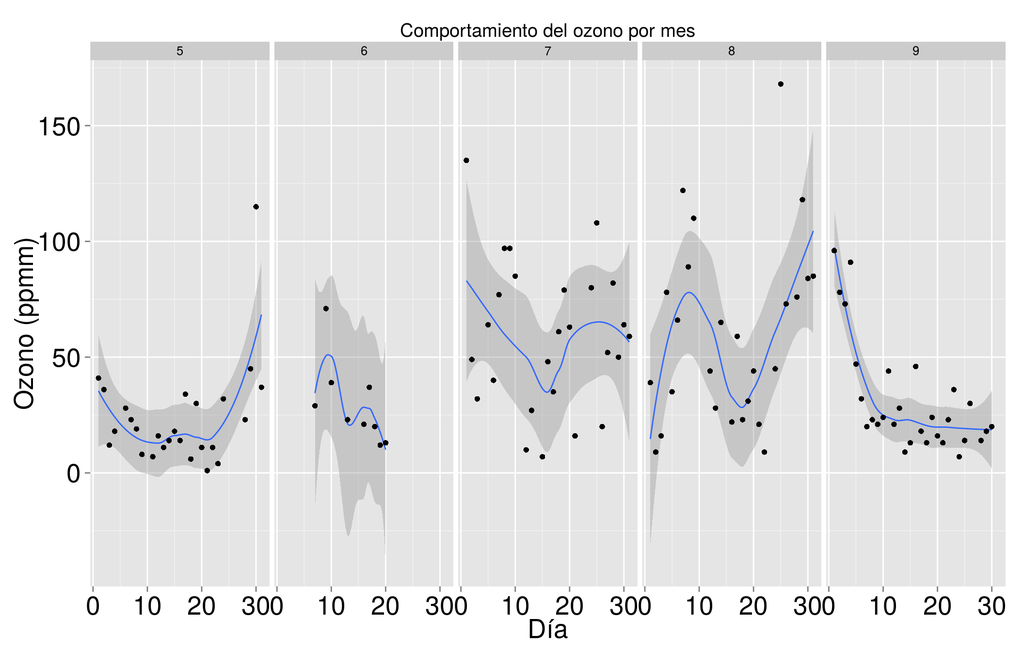

```r
require(ggplot2)
g1 <- ggplot(subset(airquality, !is.na(Ozone)),
             aes(Day, Ozone))
g1 + geom_smooth() +
     facet_grid(. ~ Month) +
     geom_point() +
     ggtitle("Comportamiento del ozono por mes") +
     xlab("Día") +
     ylab("Ozono (ppmm)")+
     theme(axis.title.y = element_text(size=20),
      axis.title.x = element_text(size=20),
      axis.text.x=element_text(size = 20, color = "black"),
      axis.text.y=element_text(color="black", size= 20))
```

```
## geom_smooth: method="auto" and size of largest group is <1000, so using loess. Use 'method = x' to change the smoothing method.
## geom_smooth: method="auto" and size of largest group is <1000, so using loess. Use 'method = x' to change the smoothing method.
## geom_smooth: method="auto" and size of largest group is <1000, so using loess. Use 'method = x' to change the smoothing method.
## geom_smooth: method="auto" and size of largest group is <1000, so using loess. Use 'method = x' to change the smoothing method.
## geom_smooth: method="auto" and size of largest group is <1000, so using loess. Use 'method = x' to change the smoothing method.
```

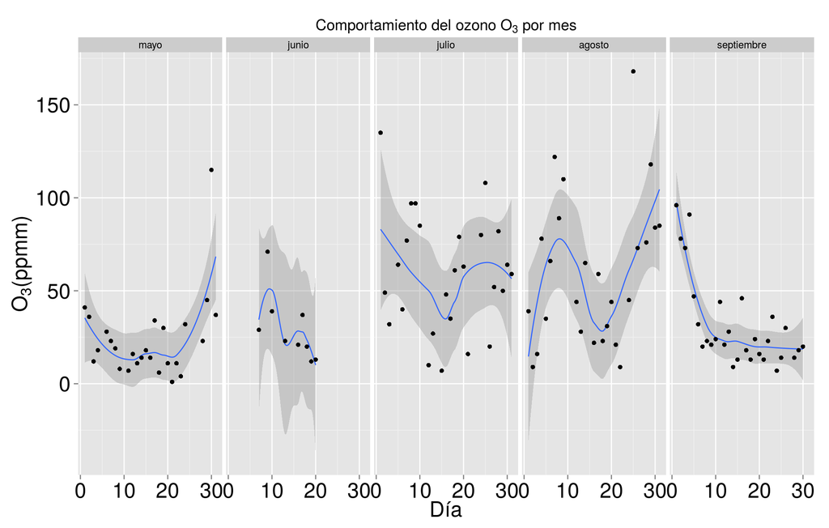

```r
require(ggplot2)
fecha1 <- as.Date(paste(with(airquality,seq(min(Month),max(Month))),"01"), format = "%m%d")
nombreMeses <- format(fecha1,"%B")
airquality <- transform(airquality, Mes = factor(Month, labels = nombreMeses))
g1 <- ggplot(subset(airquality, !is.na(Ozone)), aes(Day, Ozone))
g1 + geom_smooth() +
     facet_grid(. ~ Mes) +
     geom_point() +
     ggtitle(expression(paste("Comportamiento del ozono ",O[3]," por mes"))) +
     xlab("Día") + ylab(expression(paste(O[3], "(ppmm)")))+
theme(axis.title.y = element_text(size=20),
      axis.title.x = element_text(size=20),
      axis.text.x=element_text(size = 20, color = "black"),
      axis.text.y=element_text(color="black", size= 20))
```

```
## geom_smooth: method="auto" and size of largest group is <1000, so using loess. Use 'method = x' to change the smoothing method.
## geom_smooth: method="auto" and size of largest group is <1000, so using loess. Use 'method = x' to change the smoothing method.
## geom_smooth: method="auto" and size of largest group is <1000, so using loess. Use 'method = x' to change the smoothing method.
## geom_smooth: method="auto" and size of largest group is <1000, so using loess. Use 'method = x' to change the smoothing method.
## geom_smooth: method="auto" and size of largest group is <1000, so using loess. Use 'method = x' to change the smoothing method.
```

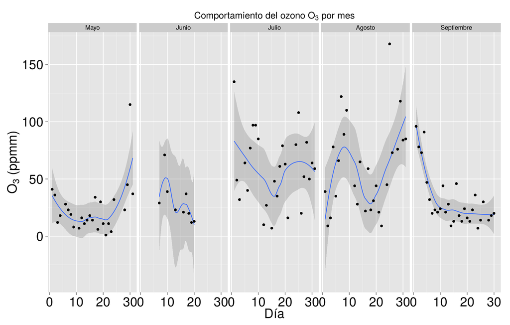

```r
require(ggplot2)
fecha1 <- as.Date(paste(with(airquality,seq(min(Month),max(Month))),"01"), format = "%m%d")
require(Hmisc)
nombreMeses <- capitalize(format(fecha1,"%B"))
airquality <- transform(airquality, Mes = factor(Month, labels = nombreMeses))
g1 <- ggplot(subset(airquality, !is.na(Ozone)), aes(Day, Ozone))
g1 + geom_smooth() +
     facet_grid(. ~ Mes) +
     geom_point() +
     ggtitle(expression(paste("Comportamiento del ozono ",O[3]," por mes"))) +
     xlab("Día") + ylab(expression(paste(O[3], " (ppmm)"))) +
theme(axis.title.y = element_text(size=20),
      axis.title.x = element_text(size=20),
      axis.text.x=element_text(size = 20, color = "black"),
      axis.text.y=element_text(color="black", size= 20))
```

### Estadísticas

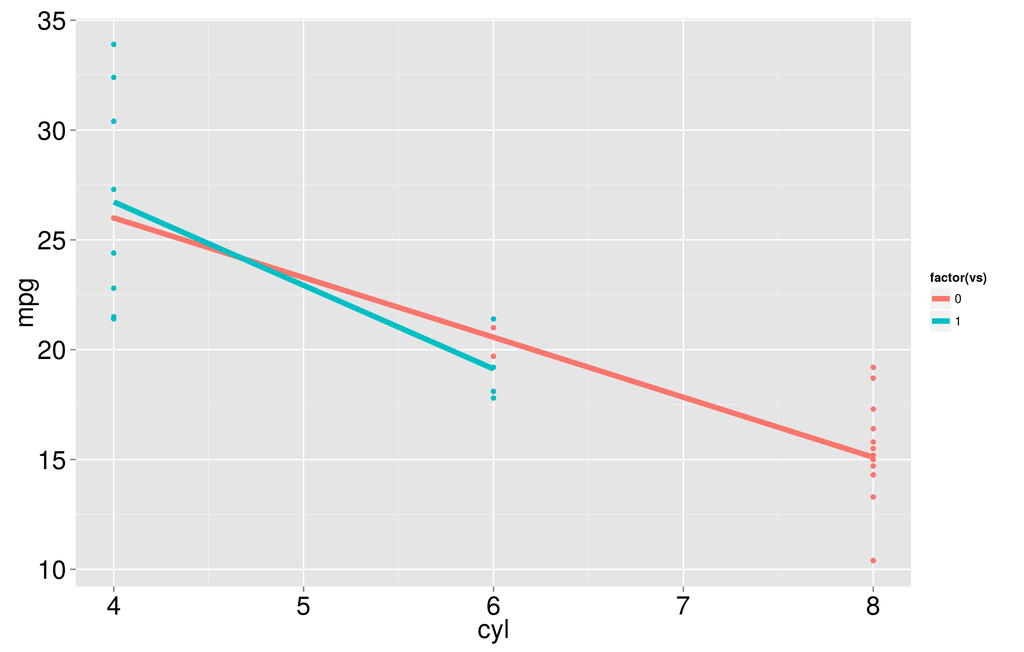

```r
g1 <- ggplot(mtcars, aes(x = cyl, y = mpg, colour = factor(vs)))
g1 +  geom_point() +
  stat_summary(fun.y = mean, geom="line", size = 2)+
theme(axis.title.y = element_text(size=20),
      axis.title.x = element_text(size=20),
      axis.text.x=element_text(size = 20, color = "black"),
      axis.text.y=element_text(color="black", size= 20))
```

```
## stat_bin: binwidth defaulted to range/30. Use 'binwidth = x' to adjust this.
```

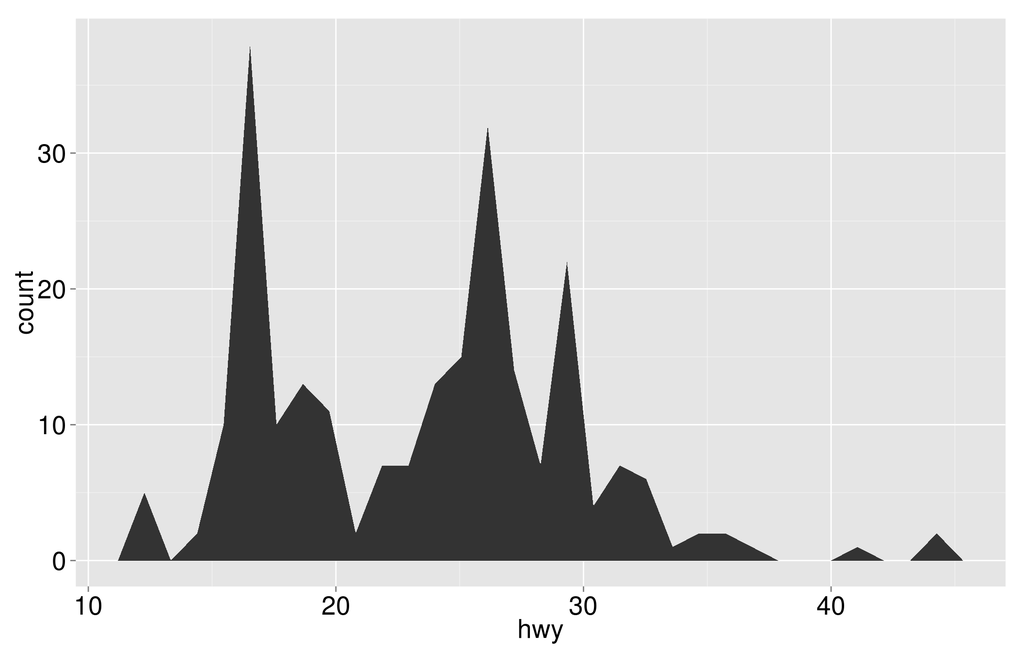

```r
g1 <- ggplot(mpg, aes(hwy))

g1 + stat_bin(aes(ymax = ..count..), geom = "area")+
theme(axis.title.y = element_text(size=20),
      axis.title.x = element_text(size=20),
      axis.text.x=element_text(size = 20, color = "black"),
      axis.text.y=element_text(color="black", size= 20))
```

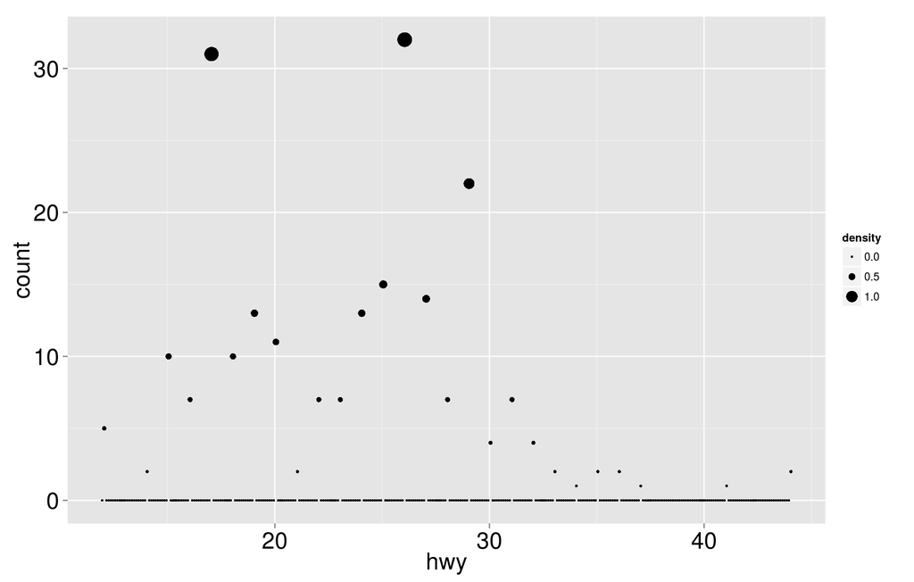

```r
g1 + stat_bin(aes(size = ..density..), binwidth = 0.1,
              geom = "point", position = "identity")+
theme(axis.title.y = element_text(size=20),
      axis.title.x = element_text(size=20),
      axis.text.x=element_text(size = 20, color = "black"),
      axis.text.y=element_text(color="black", size= 20))
```

## Referencias

- Página oficial del paquete (http://ggplot2.org).
- Página de recetas (http://www.cookbook-r.com/Graphs/).
- Referencia rápida (http://sape.inf.usi.ch/quick-reference/ggplot2).
- Foro de ayuda (http://groups.google.com/group/ggplot2).
- Foro de desarrollo (http://github.com/hadley/ggplot2).